# Occurrent Emergency Department Visits for Suspected All Drug and Opioid Overdose

County 1

January 14, 2019

The following report contains a review of information on emergency department (ED) visits for suspected all drug, opioid, heroin, and non-heroin opioid overdoses identified in data reported to the Rapid Health Information NetwOrk (RHINO) for hospitals in County 1. *Suspected overdoses* are detected in our data by querying the contents of chief complaint and discharge diagnosis using ESSENCE Chief Complaint Discharge Diagnosis (CCDD) categories. Since these are not confirmed by lab results, counts in this report may differ from the true value. The timeframe of data for this report is from 2017-Q1 through 2018-Q3 (the first and last quarters for which data is complete for ≥75% of EDs in County 1). At the time of creating this report, 100% of hospitals in County 1 were sending data to Washington State’s syndromic surveillance program.

*Note: please do not use the data in this report for public dissemination*

[figure not shown]

**Table 1.** *Mean rate of overdose visits per 10,000 ED visits from 2017-Q1 through 2018-Q3, % above or below the mean statewide for each drug category*

| Drug Category | Mean rate per 10,000 ED visits | % Above or below statewide rate |
| --- | --- | --- |
| CDC All Drug v1 CCDD Category | 57.1 | 31% below |
| CDC Opioid Overdose v2 CCDD Category | 11.4 | 58% below |
| CDC Heroin Overdose v4 CCDD Category | 4.7 | 51% below |
| Non-Heroin Opioid Overdose | 6.7 | 61% below |

**Table 2.** *Quarterly ED visit counts for overdose by category from 2017-Q1 through 2018-Q3.*

| Quarter Year | All Drug | Opioid | Heroin | Non-Heroin Opioid |
| --- | --- | --- | --- | --- |
| 2017-Q1 | 192 | 39 | 16 | 23 |
| 2017-Q2 | 212 | 43 | 16 | 27 |
| 2017-Q3 | 199 | 49 | 20 | 29 |
| 2017-Q4 | 201 | 36 | 16 | 20 |
| 2018-Q1 | 192 | 33 | 15 | 18 |
| 2018-Q2 | 204 | 41 | 17 | 24 |
| 2018-Q3 | 194 | 38 | 15 | 23 |
| Total | 1394 | 279 | 115 | 164 |

**Table 3.** *Counts and proportions of suspected overdose ED visits by demographics from 2017-Q1 through 2018-Q3.* Other race includes visits with more than one race code or codes outside of the other defined race categories. Discharge dispositions where the patient was transferred to another healthcare facility were categorized as “transferred”. Dispositions where the patient was discharged to non-healthcare facility setting (eg home, paid caregiver, custody of law enforcement) were categorized as “discharged”. Discharge disposition is inconsistent from facility to facility. Some facilities send final discharge disposition at end of care and others send working disposition when patient is admitted as an inpatient.

|  | All Drugs n | All Drugs % | Opioid n | Opioid % | Heroin n | Heroin % | Non-Heroin Opioid n | Non-Heroin Opioid % |
| --- | --- | --- | --- | --- | --- | --- | --- | --- |
| Total | 1394 | 100 % | 279 | 100 % | 115 | 100 % | 164 | 100 % |
| **Admitted as Inpatient** |  |  |  |  |  |  |  |  |
| No | 980 | 70.3 % | 188 | 67.4 % | 96 | 83.5 % | 92 | 56.1% |
| Yes | 414 | 29.7 % | 91 | 32.6 % | 19 | 16.5 % | 72 | 43.9% |
| **Deceased** |  |  |  |  |  |  |  |  |
| No | 1384 | 99.3 % | 276 | 98.9 % | 115 | 100 % | 161 | 98.2% |
| Yes | 10 | 0.7 % | 3 | 1.1 % | 0 | 0% | 3 | 1.8% |
| **Race** |  |  |  |  |  |  |  |  |
| White | 1255 | 90 % | 260 | 93.2 % | 104 | 90.4 % | 156 | 95.1% |
| Other Race | 139 | 10 % | 19 | 6.8 % | 11 | 9.6 % | 8 | 4.9% |
| **Sex** |  |  |  |  |  |  |  |  |
| Female | 769 | 55.2 % | 93 | 33.3 % | 26 | 22.6 % | 67 | 40.9% |
| Male | 623 | 44.7 % | 185 | 66.3 % | 89 | 77.4 % | 96 | 58.5% |
| Unknown | 2 | 0.1 % | 1 | 0.4 % | 0 | 0% | 1 | 0.6% |
| **Age Group** |  |  |  |  |  |  |  |  |
| 11-44 | 918 | 65.9 % | 178 | 63.8 % | 92 | 80 % | 86 | 52.4% |
| 45-64 | 287 | 20.6 % | 63 | 22.6 % | 20 | 17.4 % | 43 | 26.2% |
| 65+ | 179 | 12.8 % | 35 | 12.5 % | 0 | 0% | 35 | 21.3% |
| Unknown | 10 | 0.7 % | 3 | 1.1 % | 3 | 2.6 % | 0 | 0% |
| **County Resident** |  |  |  |  |  |  |  |  |
| Resident | 1177 | 84.4 % | 236 | 84.6 % | 96 | 83.5 % | 140 | 85.4% |
| Non-Resident | 217 | 15.6 % | 43 | 15.4 % | 19 | 16.5 % | 24 | 14.6% |

**Figure 2.** All graphs show suspected overdose ED visits by age and sex for hospitals from 2017-Q1 through 2018-Q3. Visits with unknown age or sex were not included in these graphs. *Top Left*: All Drug v1 CCDD Category. *Top Right*: Opioid Overdose v2 CCDD Category. *Bottom Left*: Heroin Overdose v4 CCDD Category. *Bottom Right*: Non-heroin Opioid Overdose Visits.

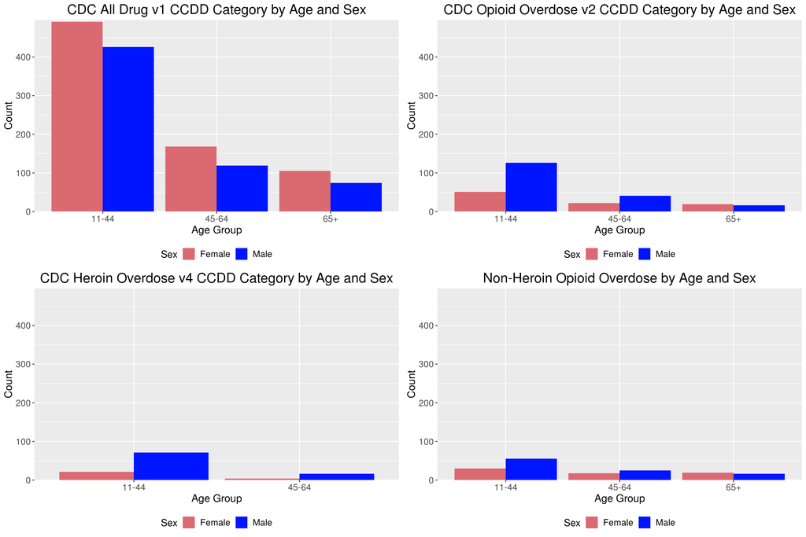

**Table 4.** *ED Visit counts and percents for suspected overdose visits by category from 2017-Q1 through 2018-Q3, by facilities within County 1*

| Facility | Prod Date* | All Drugs n | All Drugs % | Opioid n | Opioid % | Heroin n | Heroin % | Non-Heroin Opioid n | Non-Heroin Opioid % |
| --- | --- | --- | --- | --- | --- | --- | --- | --- | --- |
| Facility 1 | Date 1 | 719 | 51.6 % | 139 | 49.8 % | 66 | 57.4 % | 73 | 44.5% |
| Facility 2 | Date 2 | 675 | 48.4 % | 140 | 50.2 % | 49 | 42.6 % | 91 | 55.5% |

* Indicates the date the facility began contributing data to NSSP ESSENCE

**Table 5.** *Breakdown of suspected all drug visit counts and percents of County 1 residents and where they were treated 2017-Q1 through 2018-Q3.* This table includes all drug ED visits of patients with residence County 1 code regardless of where they were treated.

| County | n | % |
| --- | --- | --- |
| County 1 | 1177 | 98.6 % |
| County 2 | 11 | 0.9 % |
| County 3 | 6 | 0.5 % |
| Total | 1194 | 100 % |

**Notes on the data:**

- Data was pulled for this report on 14 January, 2019.
- Records restricted to patients ≥11 years old.
- Includes all records from facilities located in the county, regardless of patient location of residence.
- Suspected overdose visits may include visits in which substance use/abuse is mentioned rather than an acute overdose.
- Data are preliminary based on information available reported to RHINO and may change. Sensitivity and specificity rely heavily on the completeness and detail provided in emergency department records. As a result, some visits for true overdoses may be missed and others may be misclassified as an overdose.

**Syndromes used :**

1. [**CDC All Drug v1 query**](https://www.surveillancerepository.org/cdc-all-drug-v1)
2. [**CDC Opioid Overdose v2 query**](https://www.surveillancerepository.org/cdc-opioid-v1)
3. [**CDC Heroin Overdose v4 query**](https://www.surveillancerepository.org/cdc-heroin-v3)
4. **Non-Heroin Opioid Overdose**: Calculated by subtracting Heroin Overdose v4 CCDD Category counts from Opioid Overdose v2 CCDD Category counts